# 4. Dimensionality reduction techniques

#### 4.2.2 PCA on standardised data

When we standardise the data, we can see in the summary that in the first principal component (*PC1*), several variables show similar values, indicating that *PC1* explains around a third to half of the variation in most variables. *PC2* shows the highest values for *Labo.FM* and *Parli.F*, indicating that this PC describes the most variation in these variables (-0.72 and -0.65, respectively). When we print the percentages of the variance, we can see that *PC1* explains around 54%, and *PC2* around 16% of the variance, respectively.

```r
# scale human data
human_std <- scale(human_country_as_row)
pca_human <- prcomp(human_std)
pca_human
```

```
## Standard deviations (1, .., p=8):
## [1] 2.0708380 1.1397204 0.8750485 0.7788630 0.6619563 0.5363061 0.4589994
## [8] 0.3222406
##
## Rotation (n x k) = (8 x 8):
##                   PC1         PC2         PC3         PC4        PC5
## Edu2.FM    0.35664370 -0.03796058 -0.24223089 -0.62678110 -0.5983585
## Labo.FM   -0.05457785 -0.72432726 -0.58428770 -0.06199424  0.2625067
## Edu.Exp    0.42766720 -0.13940571 -0.07340270  0.07020294  0.1659678
## Life.Exp   0.44372240  0.02530473  0.10991305  0.05834819  0.1628935
## GNI        0.35048295 -0.05060876 -0.20168779  0.72727675 -0.4950306
## Mat.Mor   -0.43697098 -0.14508727 -0.12522539  0.25170614 -0.1800657
## Ado.Birth -0.41126010 -0.07708468  0.01968243 -0.04986763 -0.4672068
## Parli.F    0.08438558 -0.65136866  0.72506309 -0.01396293 -0.1523699
##                   PC6         PC7         PC8
## Edu2.FM    0.17713316  0.05773644 -0.16459453
## Labo.FM   -0.03500707 -0.22729927  0.07304568
## Edu.Exp   -0.38606919  0.77962966  0.05415984
## Life.Exp  -0.42242796 -0.43406432 -0.62737008
## GNI        0.11120305 -0.13711838  0.16961173
## Mat.Mor    0.17370039  0.35380306 -0.72193946
## Ado.Birth -0.76056557 -0.06897064  0.14335186
## Parli.F    0.13749772  0.00568387  0.02306476
```

```r
# create and print out a summary of pca_human
s <- summary(pca_human)

# rounded percentages of variance captured by each PC
pca_pr <- round(1*s$importance[2, ], digits = 5)

# print out the percentages of variance
pca_pr
```

```
##     PC1     PC2     PC3     PC4     PC5     PC6     PC7     PC8
## 0.53605 0.16237 0.09571 0.07583 0.05477 0.03595 0.02634 0.01298
```

```r
# create object pc_lab to be used as axis labels
paste0(names(pca_pr), " (", pca_pr, "%)")
```

```
## [1] "PC1 (0.53605%)" "PC2 (0.16237%)" "PC3 (0.09571%)" "PC4 (0.07583%)"
## [5] "PC5 (0.05477%)" "PC6 (0.03595%)" "PC7 (0.02634%)" "PC8 (0.01298%)"
```

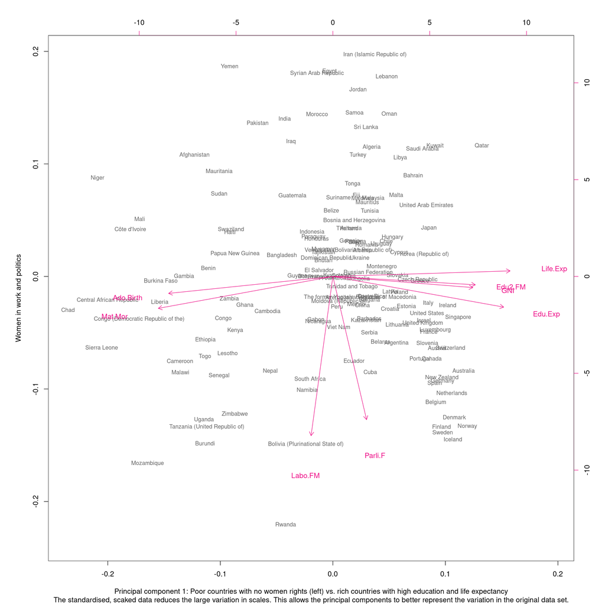

```r
# draw a biplot
plot <- biplot(pca_human, cex = c(0.8, 1), col = c("grey40", "deeppink2"),
               xlab = "Principal component 1: Poor countries with no women rights (left) vs. rich countries with high education and life expectancy", ylab = "Women in work and politics",
       sub = "The standardised, scaked data reduces the large variation in scales. This allows the principal components to better represent the variation in the original data set.")
```

In the biplot above, we can see that *Labo.RM* and *Parli.F* are located very close to each other, but that also *Mat.Mor* and *Ado.Birth*, and *Edu.Exp*, *Edu.FM*, *Life.Exp*, and *GNI* are very clustered. Looking at the different axes (*PC1* = x-axis, *PC2* = y-axis), we can again see that the *PC1* differentiates largely between *Ado.Birth* and *Mat.Mor* as one group on the left and *Life.Exp*, *Edu.Exp*, *Edu2.FM*, and *GNI* as another group on the right. A third group is represented by *Labo.FM* and *Parli.FM*. The latter is the only group where *PC2* captures a difference in the variance compared to all other variables.

As evident in the two biplots, the results from the raw and standardised data are very different. Looking back at the raw data, we can see that the different variables vary largely in scales. While *Edu2.FM* and *Labo.FM* range from 0.17 to 1.50 and 0.19 to 1.04, respectively, *GNI* ranges from 581 to 123124. The within-variable range and scale therefore differ widely. Since the variance in *GNI* is so large both in distance and number, it dominates the PCA when the variables are not scaled. In the scaled data set, however, it is possible to capture the differences in the variance of the variables since their values are much closer to one another. This allows us to better visualise the important information and groups in the data set.

A proper pnterpretation of the PCA is difficult. Nevertheless, it can be assumed that the maternal mortality ratio (*Mat.Mor*) and adolescent birth rate (*Ado.Birth*) are clustered around countries such as Liberia, Congo, Chad, and the Central African Republic because women might not have access to education and/ or contraceptives. As a result, women seem get pregnant very early (between 10 and 14 years old), but risk death die during birth. The cluster of *Life.Exp*, *Edu.Exp*, *Edu2.FM*, and *GNI* might indicate that the higher the life expectancy and expected years of schooling, the higher the Gross National Income per capita. Since most countries situated on the right of the biplot are developed countries with a high GNI, this interpretation seems likely. *Labo.FM* and *Parli.F* are most likely clustered because women are much more likely to be involved in politics if they work.

### 4.3 Multipe Correspondence Analysis (MCA)

The Multiple Correspondence Analysis (MCA) is a generalisation of PCA, and used when the variables to be analysed are categorical instead of quantitative. The goal is to identify groups of individuals with similar answers to asked questions, and the associations between the categories of the variables.

To show how MCA works, we use the tea data from the FactoMineR package. In this data set, 300 people (observations / rows) were asked 4 personal questions, 18 questions on how they drink tea, and 12 questions on how they perceive the products. To simplify our analysis, we choose six (6 columans) variables in our MCA, of which all are categorical levels. From the summary, we can see what kind of tea they chose to drink, how they drank it, when they drank it and where they got the tea from. The distribution is well-shown in the histograms below.

Source: http://sthda.com/english/articles/31-principal-component-methods-in-r-practical-guide/114-mca-multiple-correspondence-analysis-in-r-essentials

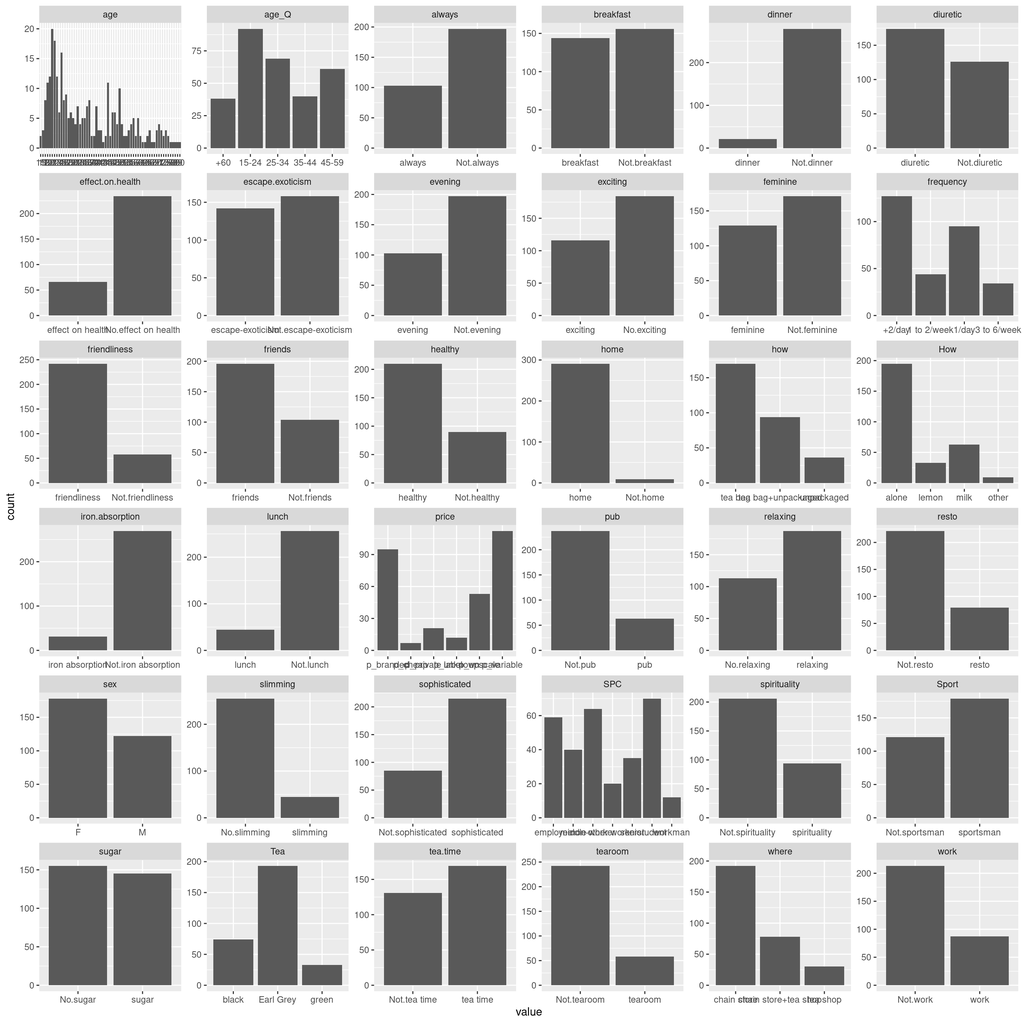

```
## 'data.frame':    300 obs. of  6 variables:
##  $ Tea  : Factor w/ 3 levels "black","Earl Grey",..: 1 1 2 2 2 2 2 1 2 1 ...
##  $ How  : Factor w/ 4 levels "alone","lemon",..: 1 3 1 1 1 1 1 3 3 1 ...
##  $ how  : Factor w/ 3 levels "tea bag","tea bag+unpackaged",..: 1 1 1 1 1 1 1 1 2 2 ...
##  $ sugar: Factor w/ 2 levels "No.sugar","sugar": 2 1 1 2 1 1 1 1 1 1 ...
##  $ where: Factor w/ 3 levels "chain store",..: 1 1 1 1 1 1 1 1 2 2 ...
##  $ lunch: Factor w/ 2 levels "lunch","Not.lunch": 2 2 2 2 2 2 2 2 2 2 ...
```

```
##         Tea         How                      how           sugar
##  black    : 74   alone:195   tea bag           :170   No.sugar:155
##  Earl Grey:193   lemon: 33   tea bag+unpackaged: 94   sugar   :145
##  green    : 33   milk : 63   unpackaged        : 36
##                  other:  9
##                   where           lunch
##  chain store         :192   lunch    : 44
##  chain store+tea shop: 78   Not.lunch:256
##  tea shop            : 30
##
```

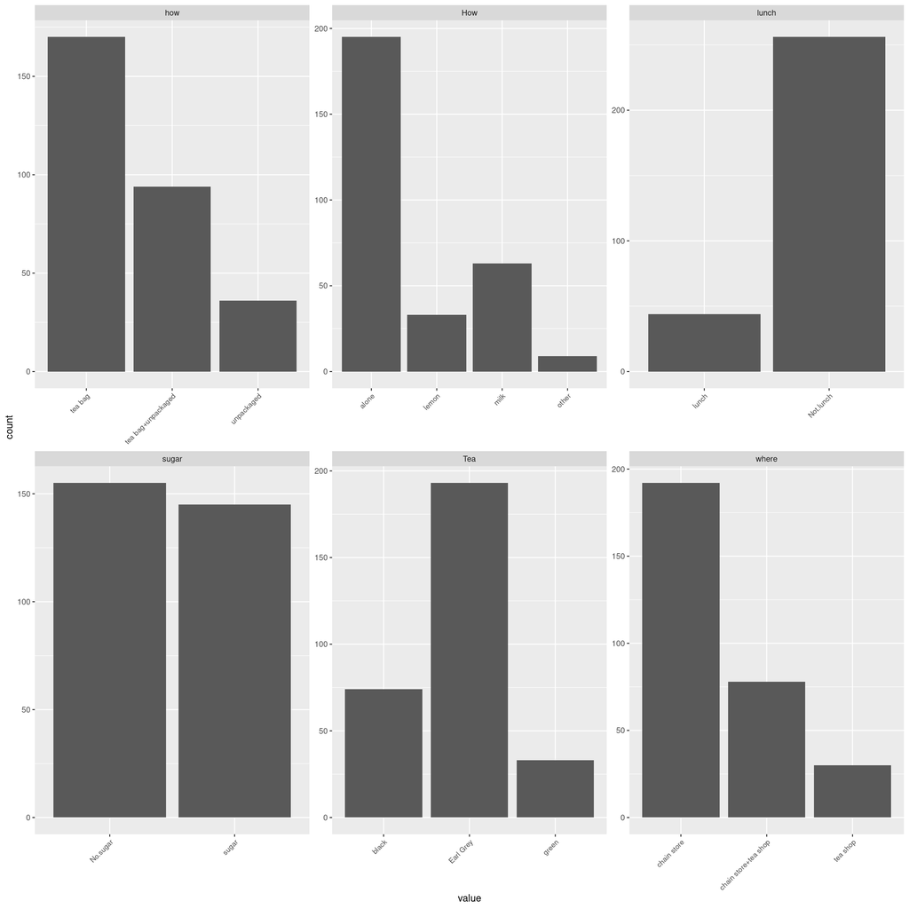

There are several ways to assess the results of the MCA. If we want to know the proportion of variances retained by different dimensions, we can look at the so-called screeplot. There, we can see that the first dimension (*Dim. 1*) explains 15.2% of the variance in the data set, *Dim. 2* 14.2%, and so on. To explain all the variation in the data set, 11 dimensions are needed (see summary output from *eig.val*).

```r
# multiple correspondence analysis
library(FactoMineR)
mca <- MCA(tea_time, graph = FALSE)

#install.packages("factoextra")
library(factoextra)
# get proportion of variances retained by different dimensions
eig.val <- get_eigenvalue(mca)
eig.val
```

```
##        eigenvalue variance.percent cumulative.variance.percent
## Dim.1  0.27937118        15.238428                    15.23843
## Dim.2  0.26092645        14.232352                    29.47078
## Dim.3  0.21933575        11.963768                    41.43455
## Dim.4  0.18943794        10.332978                    51.76753
## Dim.5  0.17722310         9.666715                    61.43424
## Dim.6  0.15617745         8.518770                    69.95301
## Dim.7  0.14375727         7.841306                    77.79432
## Dim.8  0.14126310         7.705260                    85.49958
## Dim.9  0.11717818         6.391537                    91.89111
## Dim.10 0.08660997         4.724180                    96.61529
## Dim.11 0.06205294         3.384706                   100.00000
```

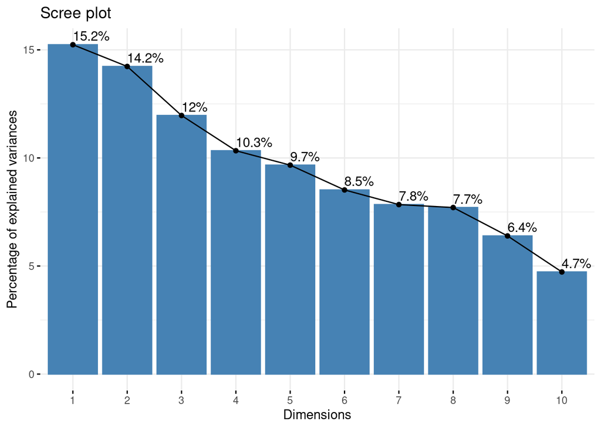

```r
# screeplot
fviz_screeplot(mca, addlabels = TRUE) # visualise percentages of variances
```

```r
# extract results for variable categories
var <- get_mca_ind(mca)
# Cos2: quality on the factor map (cos2)
head(var$cos2)
```

```
##        Dim 1     Dim 2      Dim 3      Dim 4        Dim 5
## 1 0.08622131 0.1047019 0.10430844 0.12973506 2.851705e-06
## 2 0.03646577 0.0120024 0.31368575 0.05599092 4.347624e-01
## 3 0.23148162 0.1534390 0.06910327 0.03886304 1.205832e-01
## 4 0.46021410 0.1659588 0.07321306 0.04045475 1.540730e-01
## 5 0.23148162 0.1534390 0.06910327 0.03886304 1.205832e-01
## 6 0.23148162 0.1534390 0.06910327 0.03886304 1.205832e-01
```

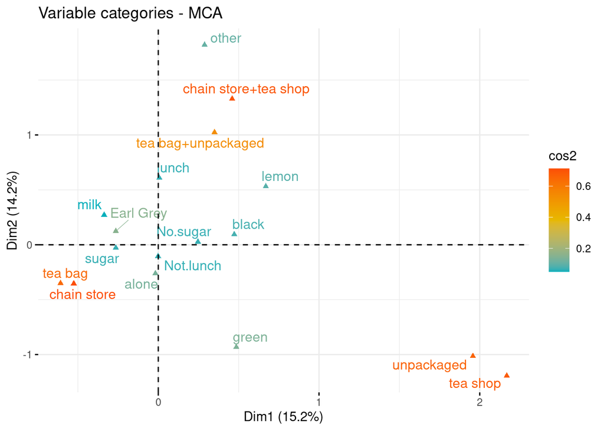

```r
# plot cos2
fviz_mca_var(mca, col.var = "cos2",
             gradient.cols = c("#00AFBB", "#E7B800", "#FC4E07"),
             repel = TRUE, # Avoid text overlapping
             ggtheme = theme_minimal())
```

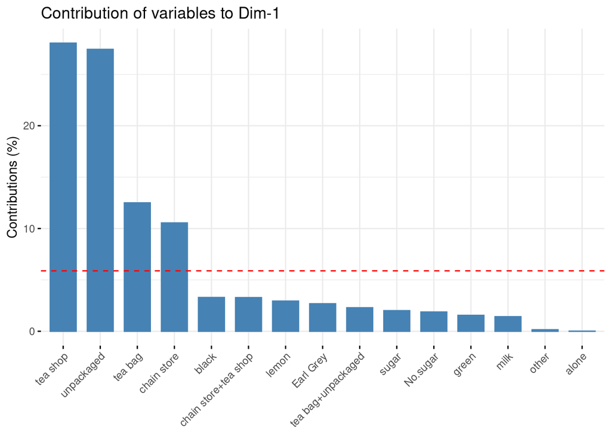

```r
# Contributions to the principal components
# Contributions of rows to dimension 1
fviz_contrib(mca, choice = "var", axes = 1, top = 15)
```

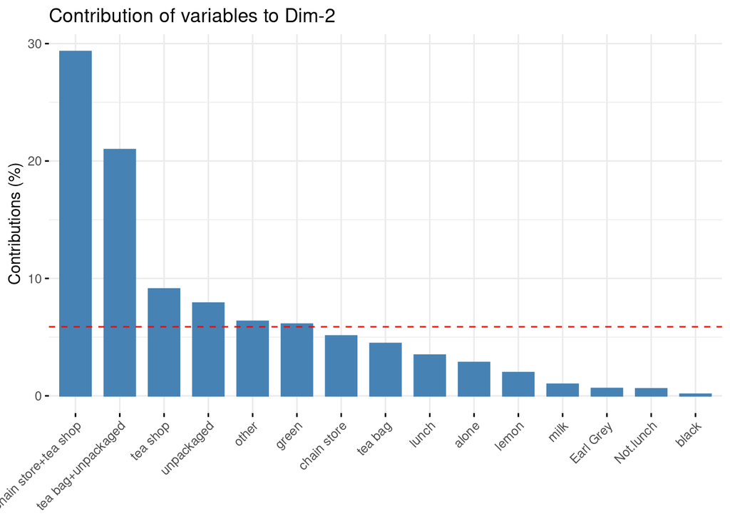

```r
# Contributions of rows to dimension 2
fviz_contrib(mca, choice = "var", axes = 2, top = 15)
```

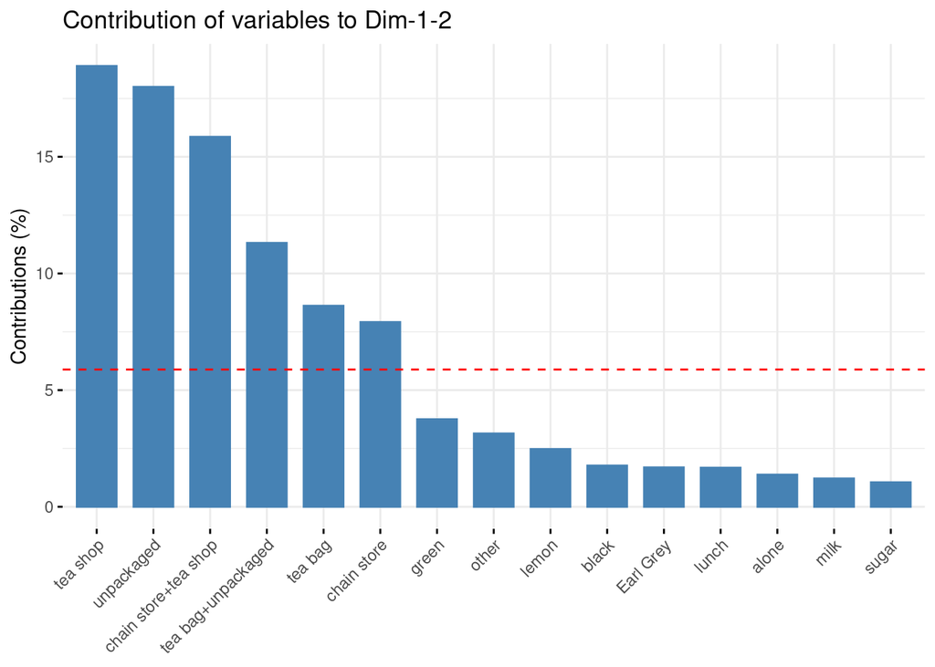

```r
# Total contribution to dimension 1 and 2
fviz_contrib(mca, choice = "var", axes = 1:2, top = 15)
```

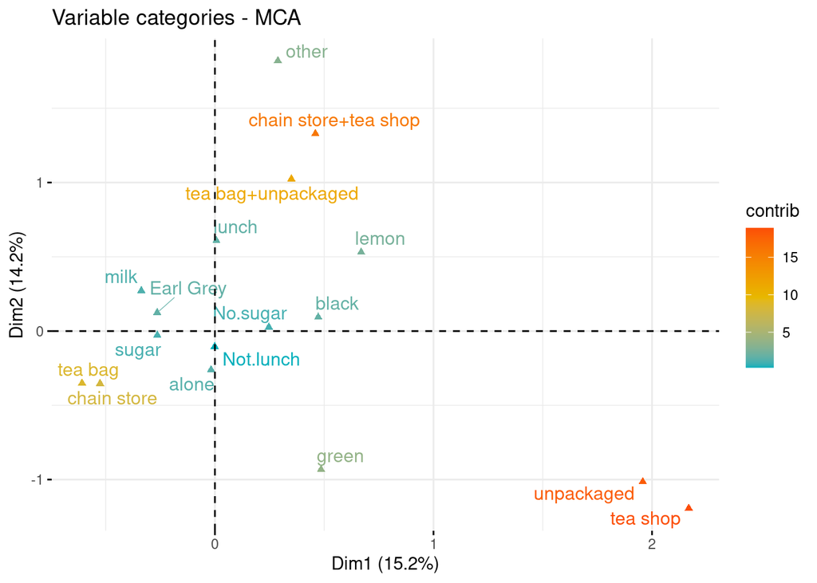

```r
# The most important (or, contributing) variable categories can be highlighted on the scatter plot as follow:
fviz_mca_var(mca, col.var = "contrib",
             gradient.cols = c("#00AFBB", "#E7B800", "#FC4E07"),
             repel = TRUE, # avoid text overlapping (slow)
             ggtheme = theme_minimal()
             )
```

Using histograms, we can evaluate the contributions of each variable to the dimensions 1 and 2 individually and combined (see above). In *dim 1*, *tea shop*, *unpackaged*, *tea bag*, and *chain store* contribute the most to the dimensions. In *dim 2*, *chain store+tea shop*, *tea bag+unpacked*, *tea shop*, *unpackaged*, *other*, and *green* are above the expected average value if contributions were uniform (red dashed line). The combined plot adds shows that *tea shop*, *unpackaged*, and *chain store+tea shop* are the most important contributions, which is again showed in a coloured scatter plot.

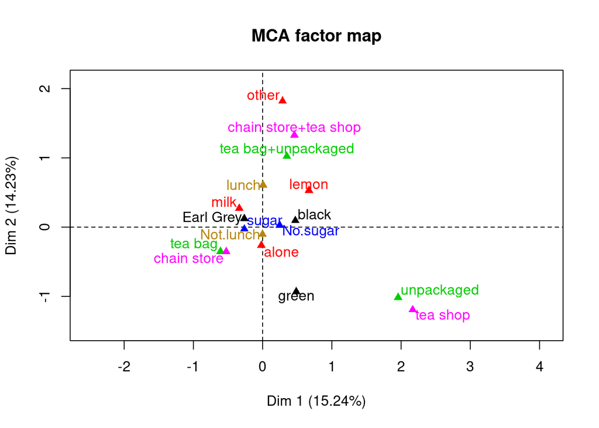

```r
# visualize MCA
plot(mca, invisible=c("ind"), graph.type = "classic", habillage = "quali")
```

Finally, we can visualise the MCA factor map (see above). The different colours show the six variable groups we chose in the beginning. Again, *tea shop* and *unpackaged* somewhat stand alone. According to *Dim 1*, we could interpret that the more “sofisticated” tea drinkers greatly enjoy good quality tea, and would rather buy unpackaged tea in a tea shop. On the other hand, “modest” tea drinkers would buy tea bags in a chain store. According to *Dim 2*, there are no great differences between tea bags and unpackaged tea, or where the tea is bought. Here we could suggest that people who drink Earl Grey might more likely add milk and sugar to their tea.